# tfcb_2020_Capstone_CWC

Cara Chao

12/14/2020

About the data:

Here we are using the same glaucoma dataset as used in the jupiter notebook, except this loos at the training and testing dataset rather than the whole. In here, we are interested in addressing these two question:

1. What is the average age of those who have glaucoma?
2. Does cornea thickness vary between those with and without glaucoma?

The first question addresses how well the training set trained the model by comparing the percentage of diagnosed patients with glaucoma between the training dataset and the test dataset. The second question further looks at whether cornea thickness is different between patients with and without glaucoma, and determining whether there is a difference in any trends before and after training the model.

## R Markdown

```r
library(tidyverse)
```

Determining the number of patients within the whole dataset that are/are not diagnosed with glaucoma

```r
# assigning datasets to variable names for the training and testing datasets.
df_train <- read.csv("dataset/ds_train.csv")
df_test <- read.csv("dataset/ds_test.csv")
```

filtering through the dataset to get only hits from subjects who are diagnosed with glaucoma.

```r
glaucoma_train <- df_train %>%
  filter(glaucoma==1)
glaucoma_train
```

```
##     RL glaucoma age ocular_pressure     MD   PSD GHT cornea_thickness
## 1   OD        1  53              24  -2.90  3.78   2              547
## 2   OS        1  53              24  -8.04 12.83   2              535
## 3   OD        1  53              24  -3.89  4.12   2              547
## 4   OS        1  53              24  -8.39 11.58   2              535
## 5   OD        1  53              24  -3.61  3.69   2              547
## 6   OS        1  53              24  -7.91 12.76   2              535
## 7   OS        1  81              28 -30.23  2.97   2              481
## 8   OS        1  55              33 -15.71 10.02   2              576
## 9   OD        1  47              34 -21.39 14.69   2              483
## 10  OS        1  47              35 -32.51  2.75   2              503
## 11  OD        1  47              34 -21.72 14.90   2              483
## 12  OS        1  47              35  32.69  2.03   2              503
## 13  OS        1  54              30 -28.09  8.82   2              452
## 14  OS        1  54              30 -21.63 12.35   2              452
```

[output cut: 461 more lines]

```r
avg_g_train <- glaucoma_train%>%
  mutate(mean_glaucoma_train = mean(age))%>%
print()
```

```
##     RL glaucoma age ocular_pressure     MD   PSD GHT cornea_thickness
## 1   OD        1  53              24  -2.90  3.78   2              547
## 2   OS        1  53              24  -8.04 12.83   2              535
## 3   OD        1  53              24  -3.89  4.12   2              547
## 4   OS        1  53              24  -8.39 11.58   2              535
## 5   OD        1  53              24  -3.61  3.69   2              547
## 6   OS        1  53              24  -7.91 12.76   2              535
## 7   OS        1  81              28 -30.23  2.97   2              481
## 8   OS        1  55              33 -15.71 10.02   2              576
## 9   OD        1  47              34 -21.39 14.69   2              483
## 10  OS        1  47              35 -32.51  2.75   2              503
## 11  OD        1  47              34 -21.72 14.90   2              483
## 12  OS        1  47              35  32.69  2.03   2              503
## 13  OS        1  54              30 -28.09  8.82   2              452
## 14  OS        1  54              30 -21.63 12.35   2              452
```

[output cut: 461 more lines]

from this, we know that the mean age within the glaucoma group is 60 years old.

filterinig through the dataset to get only hits from subjects who do not have glaucoma

```r
no_glaucoma_train <- df_train %>%
  filter(glaucoma==0)
no_glaucoma_train
```

```
##     RL glaucoma age ocular_pressure     MD   PSD GHT cornea_thickness
## 1   OD        0  62              17  -0.54  1.81   0              558
## 2   OS        0  62              17  -0.64  1.38   0              564
## 3   OD        0  66              12  -1.65  2.89   2              490
## 4   OD        0  81              13  -6.80  3.98   2              483
## 5   OD        0  55              15  -0.08  2.06   0              580
## 6   OD        0  54              15  -3.60  3.02   0              471
## 7   OD        0  22              17  -0.81  1.48   0              573
## 8   OS        0  22              17  -0.44  1.46   1              573
## 9   OS        0  74              12  -8.42  2.93   1              547
## 10  OS        0  50              17  -5.09  2.36   2              534
## 11  OS        0  50              17  -3.02  1.59   0              534
## 12  OS        0  50              17  -1.71  1.92   0              534
## 13  OS        0  48              13  -1.40  1.85   0              551
## 14  OS        0  48              13  -0.78  1.86   0              551
```

[output cut: 311 more lines]

```r
avg_no_train <- no_glaucoma_train%>%
  mutate(mean_glaucoma_train = mean(age))%>%
print()
```

```
##     RL glaucoma age ocular_pressure     MD   PSD GHT cornea_thickness
## 1   OD        0  62              17  -0.54  1.81   0              558
## 2   OS        0  62              17  -0.64  1.38   0              564
## 3   OD        0  66              12  -1.65  2.89   2              490
## 4   OD        0  81              13  -6.80  3.98   2              483
## 5   OD        0  55              15  -0.08  2.06   0              580
## 6   OD        0  54              15  -3.60  3.02   0              471
## 7   OD        0  22              17  -0.81  1.48   0              573
## 8   OS        0  22              17  -0.44  1.46   1              573
## 9   OS        0  74              12  -8.42  2.93   1              547
## 10  OS        0  50              17  -5.09  2.36   2              534
## 11  OS        0  50              17  -3.02  1.59   0              534
## 12  OS        0  50              17  -1.71  1.92   0              534
## 13  OS        0  48              13  -1.40  1.85   0              551
## 14  OS        0  48              13  -0.78  1.86   0              551
```

[output cut: 311 more lines]

The average age of the group without glaucoma is 51 years old.

This determines the mean cornea thickness in patients from the training dataset as well as the standard deviation.

```r
avg_data <- df_train %>%
  summarize(mean_cornea = mean(cornea_thickness), std_cornea = sd(cornea_thickness)) %>%
  print()
```

```
##   mean_cornea std_cornea
## 1    540.1253   33.15639
```

```r
no_glaucoma_test <- df_test %>%
  filter(glaucoma==0)
no_glaucoma_test
```

```
##    RL glaucoma age ocular_pressure     MD  PSD GHT cornea_thickness RNFL4.mean
## 1  OS        0  62              16  -0.55 1.69   0              593   97.66667
## 2  OD        0  49              20  -1.03 2.23   0              602  106.00000
## 3  OD        0  46              17   0.50 1.25   0              544  125.66667
## 4  OS        0  38              18  -2.10 2.04   0              569  109.33333
## 5  OS        0  72              16  -0.32 2.17   0              588   94.00000
## 6  OS        0  47              18  -0.45 1.77   0              593  115.33333
## 7  OD        0  56              20  -1.24 2.64   2              607  103.66667
## 8  OS        0  49              20  -1.64 1.79   0              625  111.33333
## 9  OS        0  63              17  -1.61 2.85   0              515   97.00000
## 10 OS        0  22              15  -2.81 1.44   0              527  111.00000
## 11 OS        0  17              16  -3.46 2.17   0              540   93.33333
## 12 OD        0  47              15  -0.28 1.17   0              537  100.66667
## 13 OD        0  57              20   0.86 1.65   0              570  120.00000
## 14 OD        0  26              16  -2.36 1.27   0              533  118.33333
```

[output cut: 26 more lines]

```r
avg_no_test <- no_glaucoma_test%>%
  mutate(mean_glaucoma_test = mean(age))%>%
print()
```

```
##    RL glaucoma age ocular_pressure     MD  PSD GHT cornea_thickness RNFL4.mean
## 1  OS        0  62              16  -0.55 1.69   0              593   97.66667
## 2  OD        0  49              20  -1.03 2.23   0              602  106.00000
## 3  OD        0  46              17   0.50 1.25   0              544  125.66667
## 4  OS        0  38              18  -2.10 2.04   0              569  109.33333
## 5  OS        0  72              16  -0.32 2.17   0              588   94.00000
## 6  OS        0  47              18  -0.45 1.77   0              593  115.33333
## 7  OD        0  56              20  -1.24 2.64   2              607  103.66667
## 8  OS        0  49              20  -1.64 1.79   0              625  111.33333
## 9  OS        0  63              17  -1.61 2.85   0              515   97.00000
## 10 OS        0  22              15  -2.81 1.44   0              527  111.00000
## 11 OS        0  17              16  -3.46 2.17   0              540   93.33333
## 12 OD        0  47              15  -0.28 1.17   0              537  100.66667
## 13 OD        0  57              20   0.86 1.65   0              570  120.00000
## 14 OD        0  26              16  -2.36 1.27   0              533  118.33333
```

[output cut: 67 more lines]

the mean age for those who don’t have glaucoma is 52 years old.

```r
glaucoma_test <- df_test %>%
  filter(glaucoma==1)
glaucoma_test
```

```
##    RL glaucoma age ocular_pressure     MD   PSD GHT cornea_thickness RNFL4.mean
## 1  OD        1  48              20  -5.80  8.55   2              487  104.00000
## 2  OD        1  70              23 -31.23  2.52   2              511   49.00000
## 3  OD        1  76              16  -6.85  5.11   2              517   86.33333
## 4  OS        1  35              12  -2.14  2.18   1              523   98.33333
## 5  OD        1  43              23 -10.54 12.02   2              519   63.00000
## 6  OD        1  81              28 -20.10 10.57   2              593   46.66667
## 7  OD        1  67              13  -7.39  5.54   2              552   75.66667
## 8  OS        1  47              31  -3.80  2.14   2              514   67.33333
## 9  OS        1  59              29 -32.00  2.14   2              509   30.00000
## 10 OS        1  47              31  -3.29  1.71   0              514   75.00000
## 11 OD        1  44              22 -10.20 13.41   2              519   50.33333
## 12 OD        1  63              34 -26.82  8.37   2              558   62.33333
## 13 OS        1  49              48  -5.19  5.90   2              575   84.33333
## 14 OS        1  70              13  -5.25 10.96   2              521   85.00000
```

[output cut: 46 more lines]

```r
avg_g_test <- glaucoma_test%>%
  mutate(mean_glaucoma_test = mean(age))%>%
print()
```

```
##    RL glaucoma age ocular_pressure     MD   PSD GHT cornea_thickness RNFL4.mean
## 1  OD        1  48              20  -5.80  8.55   2              487  104.00000
## 2  OD        1  70              23 -31.23  2.52   2              511   49.00000
## 3  OD        1  76              16  -6.85  5.11   2              517   86.33333
## 4  OS        1  35              12  -2.14  2.18   1              523   98.33333
## 5  OD        1  43              23 -10.54 12.02   2              519   63.00000
## 6  OD        1  81              28 -20.10 10.57   2              593   46.66667
## 7  OD        1  67              13  -7.39  5.54   2              552   75.66667
## 8  OS        1  47              31  -3.80  2.14   2              514   67.33333
## 9  OS        1  59              29 -32.00  2.14   2              509   30.00000
## 10 OS        1  47              31  -3.29  1.71   0              514   75.00000
## 11 OD        1  44              22 -10.20 13.41   2              519   50.33333
## 12 OD        1  63              34 -26.82  8.37   2              558   62.33333
## 13 OS        1  49              48  -5.19  5.90   2              575   84.33333
## 14 OS        1  70              13  -5.25 10.96   2              521   85.00000
```

[output cut: 107 more lines]

the mean age for those with glaucoma is 63 years old.

To determine whether or not there is a trend between glaucoma diagnoses and cornea thickness, we generated a plot counting the overlapping points of the cornea thickness between the control patients without glaucoma and those diagnosed with glaucoma.

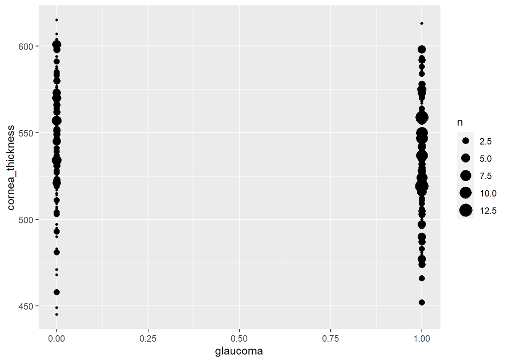

```r
df_train%>%
  select(cornea_thickness, glaucoma) %>%
  ggplot(aes(x=glaucoma, y=cornea_thickness)) +
  geom_count()
```

```r
avg_data <- df_test %>%
  summarize(mean_cornea = mean(cornea_thickness), std_cornea = sd(cornea_thickness)) %>%
  print()
```

```
##   mean_cornea std_cornea
## 1      541.04   35.45375
```

Also generated another plot counting overlapping points to see the distribution of cornea thickness among the control no glaucoma group and the diagnosed glaucoma group. This was done to compare the distribution with the training set to see if anything changed after the model was trained.

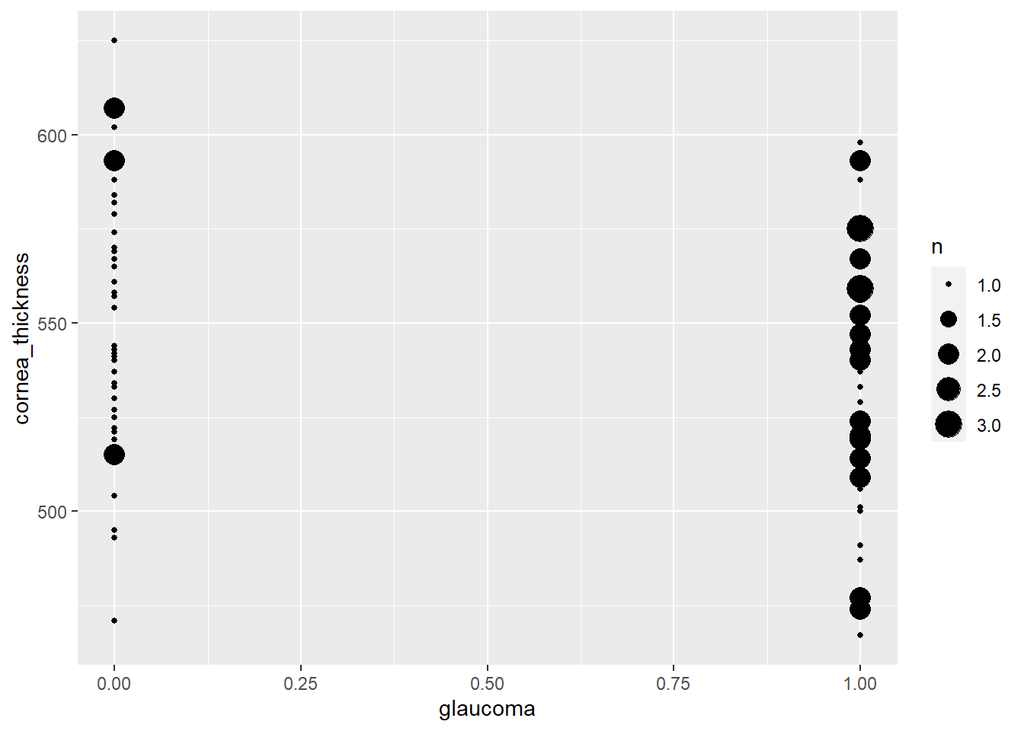

```r
df_test%>%
  select(cornea_thickness, glaucoma) %>%
  ggplot(aes(x=glaucoma, y=cornea_thickness)) +
  geom_count()
```